# MasterDoc

## Visualization via PCA

#expectations before: possible distortion caused by scale differences, principle components show batch separation after: no separation visible

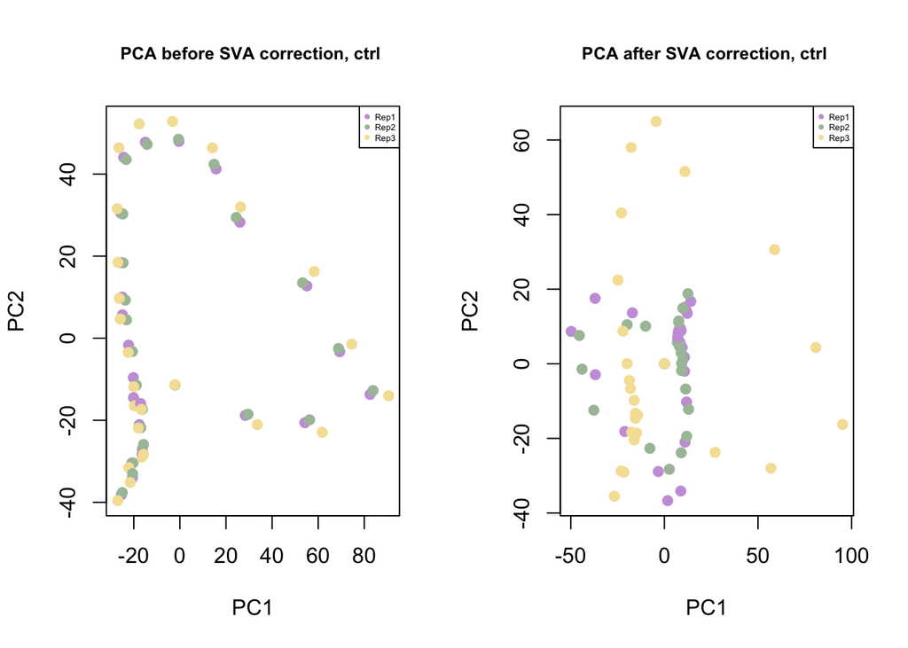

```r
# 1) PCA vorbereiten
SC_pca_before <- prcomp(t(ctrl_expr_matrix), scale. = TRUE)
SC_pca_after  <- prcomp(t(S_corrected_expr_ctrl), scale. = TRUE)
# Transposing the matrix is necessary because the observations and variables are swapped

#2. Plot:

#next to each other
par(mfrow = c(1, 2))

#PCA before correction
plot(SC_pca_before$x[, 1:2],
     col = colors,
     pch = 19,
     main = "PCA before SVA correction, ctrl ",
     cex.main=0.8,
     xlab = "PC1", ylab = "PC2")

legend("topright", legend = levels(SC_batch), col = colors, pch = 19, cex=0.4)


# PCA after correction
plot(SC_pca_after$x[, 1:2],
     col = colors,
     pch = 19,
     main = "PCA after SVA correction, ctrl ",
     cex.main=0.8,
     xlab = "PC1", ylab = "PC2")

legend("topright", legend = levels(SC_batch), col = colors, pch = 19, cex=0.4)
```

##Heatmap #expectations Before: Samples grouped by batch, and there is a clear separation of batches shown in the annotation; outliers, high variability after: samples are grouped according to biological feature, no separation

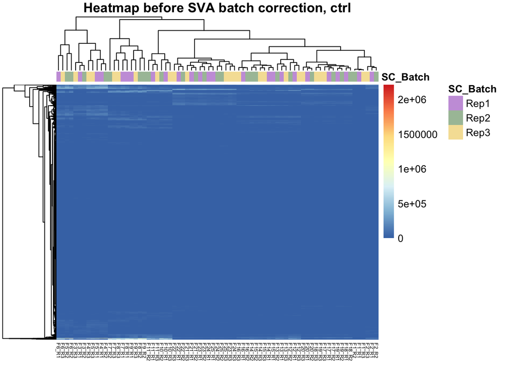

```r
#prep: Set short labels as new column names
colnames(S_corrected_expr_ctrl) <- short_labels
colnames(ctrl_expr_matrix) <- short_labels

#1. create annotation for Heatmap
annotation_col <- data.frame(SC_Batch = SC_batch)
rownames(annotation_col) <- colnames(ctrl_expr_matrix)

#2.
library(pheatmap)

# heatmap before correction
pheatmap(ctrl_expr_matrix,
         annotation_col = annotation_col,
         annotation_colors = list(SC_Batch = SC_batch_colors),
         main = "Heatmap before SVA batch correction, ctrl",
         fontsize_col=5)
```

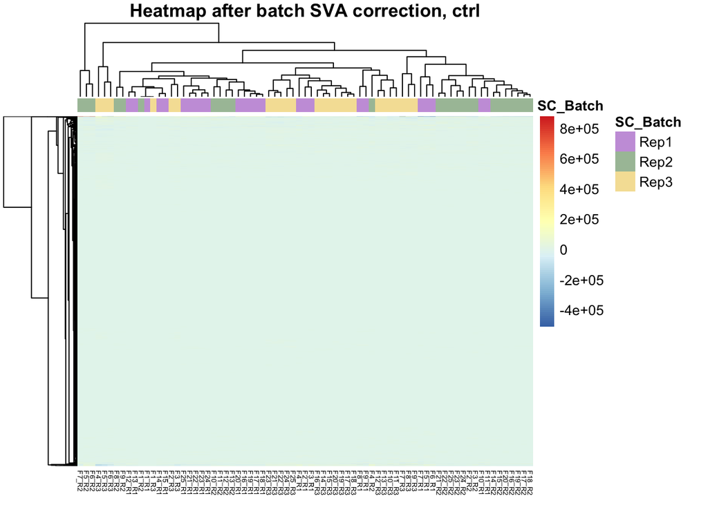

```r
# heatmap after correction
pheatmap(S_corrected_expr_ctrl,
         annotation_col = annotation_col,
         annotation_colors = list(SC_Batch = SC_batch_colors),
         main = "Heatmap after batch SVA correction, ctrl",
         fontsize_col=5)
```

#Interpretation before: there is no extreme clustering but still some visible after: slight scale difference, difference in clustering

##create df with protein column

```r
#add column with protein names again
S_corrected_expr_ctrl_df <- data.frame(
  Protein = percent_ctrl_df[, 1],
  S_corrected_expr_ctrl,
  check.names = FALSE                 # Prevents renaming of columns
)
```

## SVA RNASE

```r
# load libraries
library(sva)
library(stringr)
library(limma)

#1. create expression matrix without column of protein names
rnase_expr_matrix <- as.matrix(percent_rnase_df[, -1])

# 2.create sampleInfo
rnase_samples <- colnames(rnase_expr_matrix)

# Extract "fraction" and "replicate" information out of colnames
rnase_fraction <- str_extract(rnase_samples, "Fraction\\d+")
rnase_replicate <- str_extract(rnase_samples, "Rep\\d+")

# create sampleInfo dataframe
sampleInfo_R <- data.frame(
  rnase_fraction = factor(rnase_fraction),
  rnase_fraction = factor(rnase_fraction)
)

# 3. Create a design matrix for the model
#mod full model with known factors
mod <- model.matrix(~ fraction + replicate, data = sampleInfo_R)
#mod0 null model without descriptive factors but standard
mod0 <- model.matrix(~ 1, data = sampleInfo_R)
#models needed in order to estimate surrogate variables that model unexplained variability

# 4. Execute SVA
sva_res_rnase <- sva(rnase_expr_matrix, mod, mod0)
```

```
## Number of significant surrogate variables is:  2
## Iteration (out of 5 ):1  2  3  4  5
```

```r
#SVA checks for hidden variables that can be explained by replicates or fractions
#returns a list with surrogate variables (SV) that function as batch variables


# 5. extent design matrix with SVs
R_mod_sv <- cbind(mod, sva_res_rnase$sv)

# (6) OPTIONAL:If batch is known, ComBat can be used
# if batch is known, not the case
# batch <- sampleInfo$batch_variable
# expression_corrected <- ComBat(dat = expression_matrix, batch = batch, mod = mod)

# 7. Correct data with SV using linear regression
# lmFit and eBayes are tools from limma used to fit linear regression to expression data
fit <- lmFit(rnase_expr_matrix, mod_sv)
fit <- eBayes(fit)

# extract residues: expressions data - modelled effects (fraction + replicate + SVs)

S_corrected_expr_rnase <- residuals(fit, rnase_expr_matrix)

# S_corrected_expr_rnase contains the corrected dataset
```

```r
##create batch vector for following visualization
# 1. extract sample names to create batch labels
SR_sample_names <- colnames(rnase_expr_matrix)

# 2. create batch labels out of sample names
#create batches from replicates in order to have comparable batches
SR_batch <- sub(".*_(Rep\\d)", "\\1", SR_sample_names)
SR_batch <- factor(SR_batch, levels = c("Rep1", "Rep2", "Rep3"))

# 2. assign colors
SR_batch_colors <- c("Rep1" = "#c9a0dc", "Rep2" = "#A9C1A6", "Rep3" = "#F5E1A4")
colors <- SR_batch_colors[as.character(SR_batch)]

#4.shorten labels
short_labels <- gsub("Fraction([0-9]+)_Rep([0-9])", "F\\1_R\\2", colnames(rnase_expr_matrix))
```

## after and before boxplot

#expectation before: different levels of medians, span and spread; differences between samples caused by batches after: reduced differences

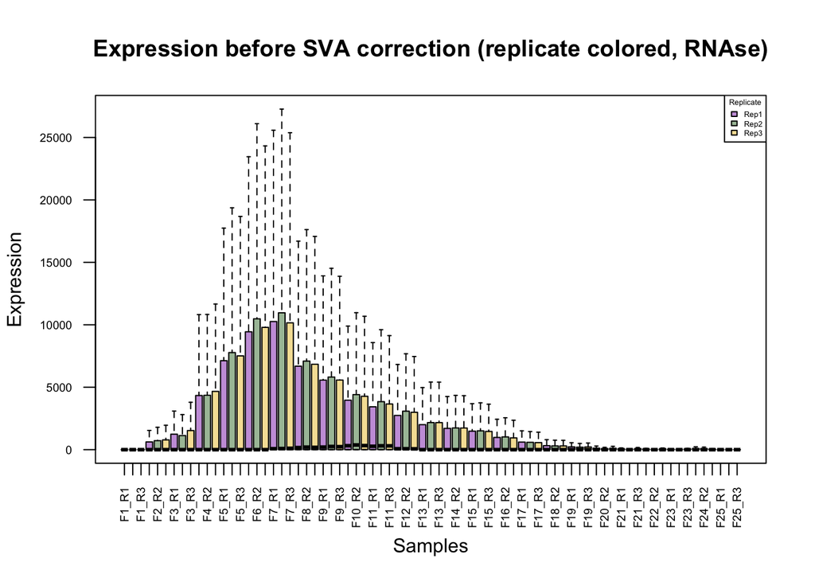

```r
# 1. Boxplot before correction
boxplot(rnase_expr_matrix,
        main = "Expression before SVA correction (replicate colored, RNAse)",
        ylab = "Expression",
        xlab = "Samples",
        las = 2,
        col = colors,
        outline = FALSE,
        cex.axis = 0.6,
        names=short_labels)
#add key
legend("topright",
       legend = names(SR_batch_colors),
       fill = SR_batch_colors,
       title = "Replicate",
       cex=0.4)
```

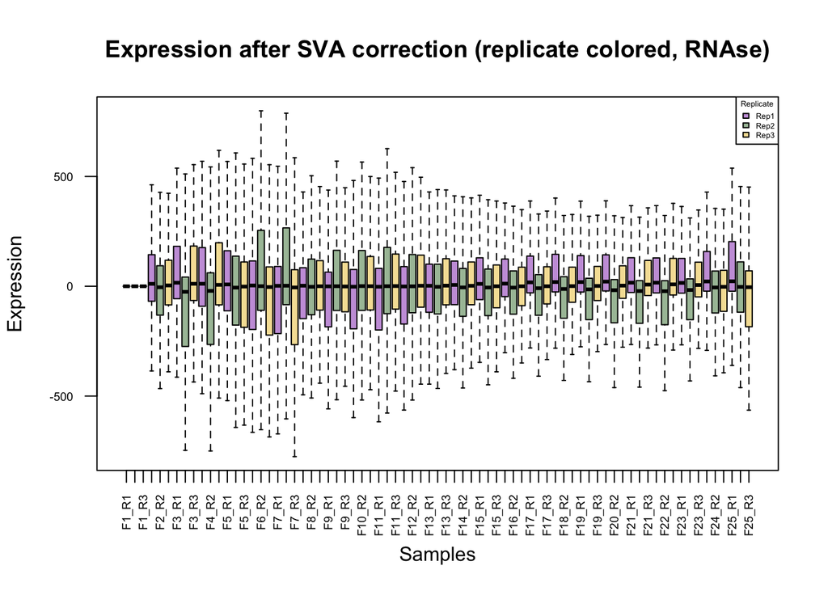

```r
# 2. Boxplot after correction
boxplot(S_corrected_expr_rnase,
        main = "Expression after SVA correction (replicate colored, RNAse)",
        ylab = "Expression",
        xlab = "Samples",
        las = 2,
        col = colors,
        outline = FALSE,
        cex.axis = 0.6,
        names=short_labels)

# add key
legend("topright",
       legend = names(SR_batch_colors),
       fill = SR_batch_colors,
       title = "Replicate",
       cex=0.4)
```

#Interpretation before: there is some differences between replicates visible but median appears to be on a similar level after: big shifts, differences in replicates not as severe

## visualisierung mittels PCA

#expectations Before: clusters of the same batch with distinct separation of clusters; distortion caused by scale differences; principle components show batch separation after: no separation visible

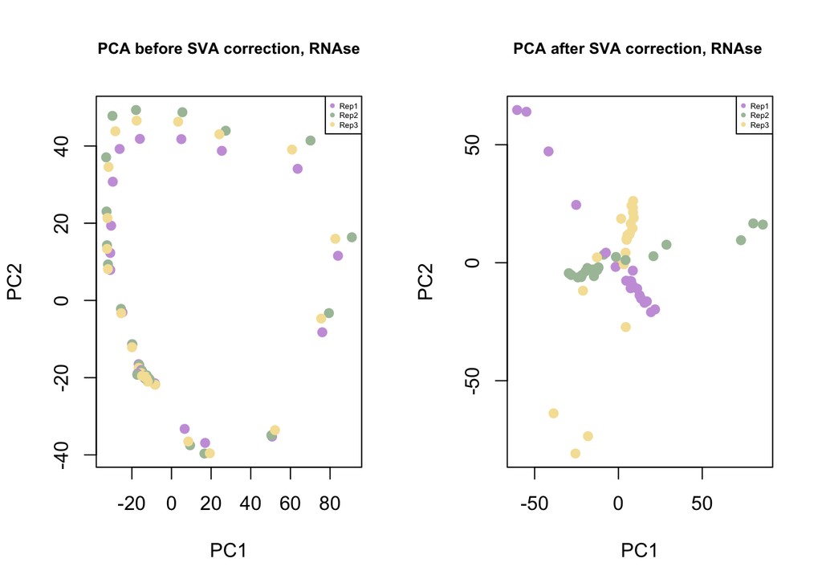

```r
# 1) prepare PCA
SR_pca_before <- prcomp(t(rnase_expr_matrix), scale. = TRUE)
SR_pca_after  <- prcomp(t(S_corrected_expr_rnase), scale. = TRUE)
# Transposing the matrix is necessary because the observations and variables are swapped

#2. plot
#next to each other
par(mfrow = c(1, 2))

#PCA before correction
plot(SR_pca_before$x[, 1:2],
     col = colors,
     pch = 19,
     main = "PCA before SVA correction, RNAse",
     cex.main=0.8,
     xlab = "PC1", ylab = "PC2")

legend("topright", legend = levels(SR_batch), col = SR_batch_colors, pch = 19,cex=0.4)

# PCA after correction
plot(SR_pca_after$x[, 1:2],
     col = colors,
     pch = 19,
     main = "PCA after SVA correction, RNAse ",
     cex.main=0.8,
     xlab = "PC1", ylab = "PC2")
legend("topright", legend = levels(SC_batch), col = colors, pch = 19,cex=0.4)
```

```r
# 5) reset layout to single plot default
par(mfrow = c(1, 1))
```

##Heatmap #expectations Before: Samples grouped by batch, and there is a clear separation of batches shown in the annotation; outliers, high variability  
After: samples are grouped according to biological feature, no separation

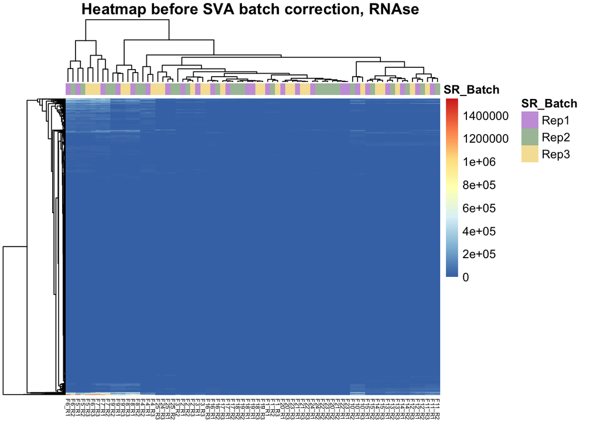

```r
#prep: Set short labels as new column names
colnames(S_corrected_expr_rnase) <- short_labels
colnames(rnase_expr_matrix) <- short_labels

# 1. create annotation for Heatmap
annotation_col <- data.frame(SR_Batch = SR_batch)
rownames(annotation_col) <- colnames(rnase_expr_matrix)

# Werte clipping basierend auf Perzentilen
expr_clipped <- S_corrected_expr_rnase
low <- quantile(expr_clipped, 0.01)
high <- quantile(expr_clipped, 0.99)

expr_clipped[expr_clipped < low] <- low
expr_clipped[expr_clipped > high] <- high

#2.
library(pheatmap)

# heatmap before correction
pheatmap(rnase_expr_matrix,
         annotation_col = annotation_col,
         annotation_colors = list(SR_Batch = SR_batch_colors),
         main = "Heatmap before SVA batch correction, RNAse ",
         fontsize_col=5)
```

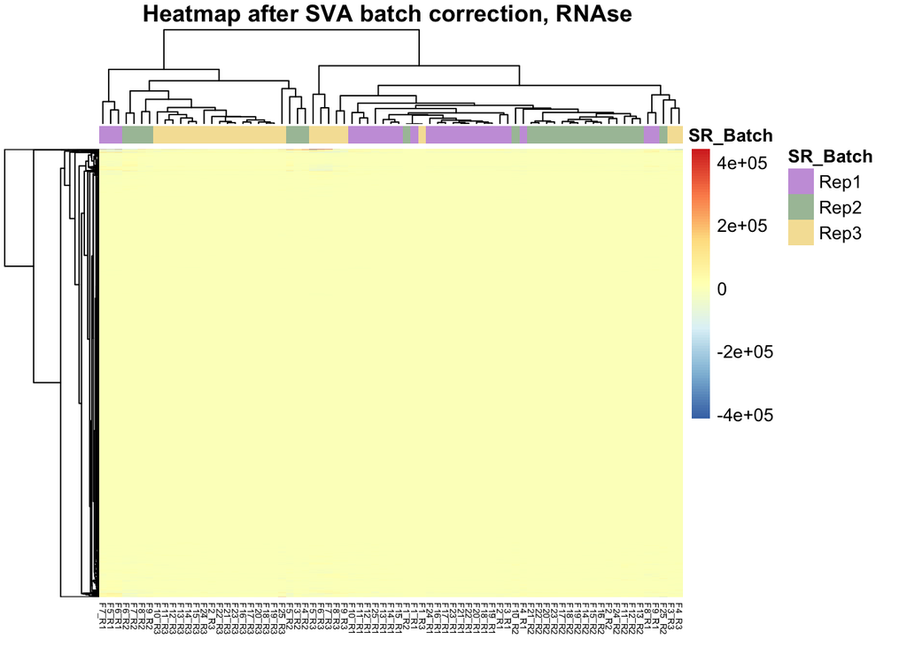

```r
# heatmap after correction
pheatmap(S_corrected_expr_rnase,
         annotation_col = annotation_col,
         annotation_colors = list(SR_Batch = SR_batch_colors),
         main = "Heatmap after SVA batch correction, RNAse ",
         fontsize_col=5)
```

#Interpretation Before: Clustering is visible in the annotation After: Difference in scale, clusters still appear

##create df with protein column

```r
#add column with protein names again
S_corrected_expr_rnase_df <- data.frame(
  Protein = percent_rnase_df[, 1],
  S_corrected_expr_rnase,
  check.names = FALSE                 # Prevents renaming of columns
)
```

# 3. shift analysis (Ellinor, Laura, Nora)

Goal: Classify proteins as RNA-dependent (RDP) or non-RNA-dependent (non-RDP) based on differences between control and RNase condition ## Tests Goal: characterize the differences between Ctrl and RNase for each protein ### Visualization of one protein Goal: get an idea of criteria that can be compared to determine significance of shift

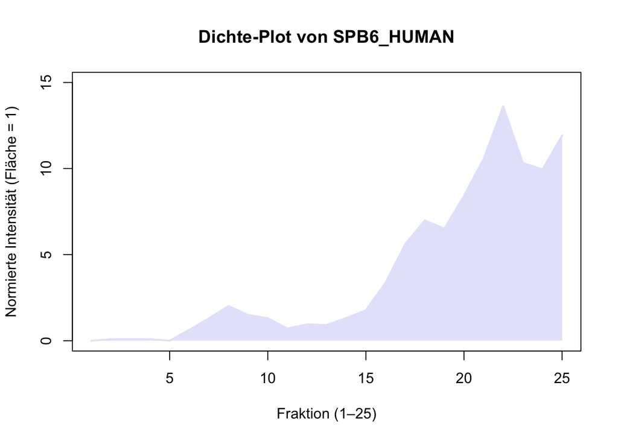

```r
#visualize distribution for one protein
protein_id <- "SPB6_HUMAN"

# extract amount of protein
intensities <- as.numeric(normalized_ctrl_df[4, 2:26 ])
fraktionen <- 1:25

# Plot
plot(fraktionen, intensities, type = "n",
       xlab = "Fraktion (1–25)", ylab = "Normierte Intensität (Fläche = 1)",
       main = paste("Dichte-Plot von", protein_id),
       ylim = c(0, max(intensities)*1.1))

 polygon(c(fraktionen, rev(fraktionen)),
          c(rep(0, length(fraktionen)), rev(intensities)),
          col = "lavender", border = NA)
  lines(fraktionen, intensities, col = "lavender", lwd = 2)
```

### maxima

Goal: find all local maxima

```r
# IdentifY position of global maxima
# recognize peaks with diff()
find_peaks_diff <- function(x, threshold = 2) {
  n <- length(x)
  peaks <- logical(n)

  dx <- diff(x)

  # Ensure maximum instead of minimum
  for (i in 2:(n-1)) {
    if (x[i] >= threshold && dx[i-1] > 0 && dx[i] < 0) {
      peaks[i] <- TRUE
    }
  }

  if (x[1] >= threshold && x[1] > x[2]) peaks[1] <- TRUE
  if (x[n] >= threshold && x[n] > x[n-1]) peaks[n] <- TRUE

  which(peaks)
}

# experimental application with a protein
process_df_peaks <- function(df, threshold = 2) {
  results <- lapply(1:nrow(df), function(i) {
    intensities <- as.numeric(df[i, 2:26])
    protein <- df[i, 1]
    peaks <- find_peaks_diff(intensities, threshold)
    list(Protein = protein, Peaks = peaks)
  })

  # save as dataframe
  df_peaks <- data.frame(
    Protein = sapply(results, `[[`, "Protein"),
    Maxima_Positions = sapply(results, function(x) {
      if (length(x$Peaks) == 0) {
        NA_character_
      } else {
        paste(x$Peaks, collapse = ",")
      }
    }),
    stringsAsFactors = FALSE
  )

  return(df_peaks)
}

# apply to our dataframe

df_peaks_CTRL <- process_df_peaks(normalized_ctrl_df, threshold = 2)
df_peaks_RNAse <- process_df_peaks(normalized_rnase_df, threshold = 2)
```

Output: all maxima for each protein were identified and localised protein concentration can be found in multiple fractions

### global maxima positions

Goal: the indifference in number of maxima between the samples for each protein pose a difficulty for the analysis of the shift -> evaluate shift based on the global maximum

```r
# Identify global maxima and their position, if present
find_global_maxima <- function(x, threshold = 2) {
  max_val <- max(x)
  if (max_val >= threshold) {
    max_positions <- which(x == max_val)
    if (length(max_positions) == 1) {
      return(max_positions)
    } else {
      middle_index <- mean(range(max_positions))
      return(middle_index)
    }
  } else {
    return(NA_real_)
  }
}

# extract intensity of the protein concentration in each fraction
process_df_global_maxima <- function(df, threshold = 2) {
  results <- lapply(1:nrow(df), function(i) {
    intensities <- as.numeric(df[i, 2:26])
    protein <- df[i, 1]
    maxima <- find_global_maxima(intensities, threshold)
    list(Protein = protein, Global_Maximum = maxima)
  })

  df_maxima <- data.frame(
    Protein = sapply(results, `[[`, "Protein"),
    Global_Maximum = sapply(results, `[[`, "Global_Maximum"),
    stringsAsFactors = FALSE
  )

  return(df_maxima)
}

# Apply to our dataframe
global_ctrl <- process_df_global_maxima(normalized_ctrl_df, threshold = 2)
global_rnase <- process_df_global_maxima(normalized_rnase_df, threshold = 2)
```

# Classification of RBP and Non-RBP according to logistic model

Goal: Apply statistical testscores to our test-model and thus determine the probability of the proteins being RBPs or Non-RBPS -> logistic model is established using 30 % of the dataset to train the model -> applying the model to the remaining data yields the predicted probability of RNA-binding for each protein ### shift distance and direction test

```r
#Shift Distance and direction based on changes in global maximum
global_ctrl$Global_Maximum <- as.numeric(as.character(global_ctrl$Global_Maximum))
global_rnase$Global_Maximum <- as.numeric(as.character(global_rnase$Global_Maximum))

# Shift distance as absolute value
raw_shift_distance <- global_rnase$Global_Maximum - global_ctrl$Global_Maximum
shift_distance <- abs(raw_shift_distance)

# determine direction
shift_direction <- ifelse(raw_shift_distance > 0, "right shift",
                   ifelse(raw_shift_distance < 0, "left shift",
                          "No Shift"))

shift_result <- data.frame(
  Protein = global_ctrl$Protein,
  Position_Control = global_ctrl$Global_Maximum,
  Position_RNase = global_rnase$Global_Maximum,
  Shift_Distance = shift_distance,
  Shift_Direction = shift_direction
)
```

- Determining the shift direction based on the position of the global maximum is not ideal, as some RBPs may later lack a clear shift direction. -> Therefore, this definition of shift direction will not be used. -> Instead, the shift direction is defined based on the center of mass test

#### skewness of shift distance

Goal: determine skewness of shift distance and check whether robust scaling can be applied -> if skewness > 1 or < -1, then robust scaling can be applied robust scaling: (x-median)/IQR -> generally used for asymmetrical distributions

```r
#skewness of Shift Distance
# extract values
x <- shift_result$Shift_Distance

# calculate skewness (Fisher-Pearson Skewness)
n <- length(x)
m3 <- sum((x - mean(x, na.rm = TRUE))^3, na.rm = TRUE) / n
s3 <- (sum((x - mean(x, na.rm = TRUE))^2, na.rm = TRUE) / n)^(3/2)
skewness <- m3 / s3
print(paste("Skewness:", round(skewness, 4)))
```

```
## [1] "Skewness: 2.8196"
```

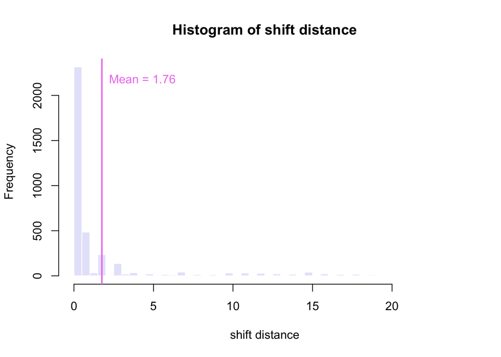

```r
# plot histogram
hist(x, breaks = 50, col = "lavender", main = "Histogram of shift distance",
     xlab = "shift distance", border = "white")
abline(v = mean(x, na.rm = TRUE), col = "violet", lwd = 2)
text(mean(x, na.rm = TRUE), par("usr")[4]*0.9,
     labels = paste0("Mean = ", round(mean(x, na.rm = TRUE), 2)),
     col = "violet", pos = 4)
```

```r
# Robust scaling function: (x - median) / IQR
robust_scale <- function(x) {
  med <- median(x, na.rm = TRUE)
  iqr <- IQR(x, na.rm = TRUE)
  scaled <- (x - med) / iqr
  return(scaled)
}

# Apply robust scaling to each variable
shift_result$Shift_Distance_scaled <- robust_scale(abs(shift_result$Shift_Distance))
```

```r
# scale to 100%
shift_result$Shift_Distance_scaled_100 <- (shift_result$Shift_Distance_scaled/25)*100
```

### change in amplitude of global maximum test

Goal:uncover a possible change in protein-complex assembly after rnase treatment calculate the amplitude of the global maximum and whether a gain or loss took place

```r
# calculate amplitude of global maximum for control measurements
get_global_amplitudes <- function(expression_df, global_ctrl) {
  amplitudes <- mapply(function(row_idx, max_pos_str) {
    max_positions <- as.numeric(unlist(strsplit(max_pos_str, ",")))

    if (length(max_positions) == 0 || all(is.na(max_positions))) {
      return(NA)
    }

    intensities <- as.numeric(expression_df[row_idx, max_positions + 1])

    paste(intensities, collapse = ",")
  },
  row_idx = 1:nrow(expression_df),
  max_pos_str = as.character(global_ctrl$Global_Maximum)

  )

  data.frame(
    Protein = expression_df[[1]],
    Amplitudes = amplitudes,
    stringsAsFactors = FALSE
  )
}
#apply function to our data
global_amplitudes_ctrl <- get_global_amplitudes(normalized_ctrl_df, global_ctrl)
```

```r
#calculate amplitude of global maximum for rnase measurments
get_global_amplitudes <- function(expression_df, global_rnase) {
  amplitudes <- mapply(function(row_idx, max_pos_str) {
    max_positions <- as.numeric(unlist(strsplit(max_pos_str, ",")))

    if (length(max_positions) == 0 || all(is.na(max_positions))) {
      return(NA)
    }

    intensities <- as.numeric(expression_df[row_idx, max_positions + 1])

    paste(intensities, collapse = ",")
  },
  row_idx = 1:nrow(expression_df),
  max_pos_str = as.character(global_rnase$Global_Maximum)

  )

  data.frame(
    Protein = expression_df[[1]],
    Amplitudes = amplitudes,
    stringsAsFactors = FALSE
  )
}

global_amplitudes_rnase <- get_global_amplitudes(normalized_rnase_df, global_rnase)
```